# TFM-Evaluación

Ana Sabater Aguado

# Uso de organismos modelo en el descubrimiento de nuevos genes relacionados con el Parkinson Juvenil

# 2. Evaluación de genes conocidos como causantes de Parkinson, genes predichos mediante machine learning como causantes de Parkinson y genes tomados de forma aleatoria

El objetivo de este trabajo es definir un mecanismo genérico de evaluación de predicciones de asociaciones (gen, enfermedad) para enfermedades genéticas monogénicas. Una vez caracterizado un conjunto de genes asociados a la enfermedad a estudiar (extrayendo los términos de ontologías de fenotipos relevantes según su prevalencia, es decir, su presencia en un número mínimo de genes de forma que garantice su robustez como fenotipos relevantes de la enfermedad), se utilizará ese listado de fenotipos relevantes y los conjuntos de genes conocidos, predichos y tomados de forma aleatoria para calibrar la cantidad de asociaciones gen-fenotipo que pueden encontrarse en las bases de datos genéticas consultadas.

El método presentado a continuación se basa en que si dichas predicciones son correctas, deberíamos asumir que reproducirán un número de asociaciones gen-fenotipo similar a la obtenida con los genes conocidos. Y si no es similar, al menos debería estar por encima del ruido. Dicho en otras palabras, el número de asociaciones debería ser mejor que el que obtendríamos prediciendo nuevos genes mediante azar.

Para la prueba con genes asociados a Parkinson, se decidió utilizar solo las bases de datos de HumanMine y MouseMine porque contenían un mayor número de genes conocidos (mayor del 90%) y devolvían más términos relevantes para la EP (prevalencia mayor del 15%, es decir, estaban presentes en al menos 5 genes conocidos).

Destacamos que todos los conjuntos de genes utilizados deben contener símbolos de genes humanos para su correcto funcionamiento.

## 2.1 Método para la obtención, filtrado y conteo de fenotipos relevantes

En este apartado presentamos una función que necesita tres parámetros:

- Lista de símbolos de genes humanos
- Función específica para la base de datos que se quiere utilizar
- Lista de términos fenotípicos relevantes para la Base de Datos y el fenómeno que se quiere estudiar

Esta función utiliza la API de una de las bases de datos utilizadas en la caracterización de los genes conocidos como causantes de un trastorno de interés a partir de la que obtiene los términos fenotípicos asociados a la lista de genes humanos. Posteriormente, filtra los fenotipos presentes en la segunda lista con la que se invoca a la función y calcula el número de genes asociados a cada fenotipo, añadiéndolos a un contador total. El resultado final de esta función es el número total de genes dentro de la primera lista utilizada asociados a los términos HP que forman parte de la segunda lista con la que se invoca.

```r
genAsociatedWithPhenotype = function (listagenes, BaseDatosphenotype, terminosFenotipos){
# Funcion generica para la obtencion de terminos a partir de una lista de genes, una funcion fenotípica y una lista para guardar los resultados de la misma
queryfunctionfromlistgenes = function(listagenes, funcionphenotype, phenotypeResultado){
  for(gen in listagenes){
    resultado = list(funcionphenotype(gen))
    if (length(resultado) != 0){
      phenotypeResultado <- c(phenotypeResultado, resultado)
    } else {
      phenotypeResultado <- c(phenotypeResultado, "gen no encontrado")

    }
  }
  names(phenotypeResultado) <- listagenes
  return(phenotypeResultado)
}
# El codigo presentado a continuacion devuelve los terminos HP para cada gen:
# Creamos una lista para almacenar los terminos HP de una lista de genes
HPobjeto = list()
# Lista generica para iterar
resultados1 = list()
# Contador para el numero total de parejas gen-fenotipo
numfenotipos = 0
# Obtencion de los terminos HP
HPresultados = queryfunctionfromlistgenes(listagenes, BaseDatosphenotype, resultados1)
# Filtrado del termino HP deseado
for (termino in terminosFenotipos) {
  misGenes = grep(termino, HPresultados)
  Genes = vector()
  for (index in misGenes){
    nombre = names(HPresultados[index])
    Genes = c(Genes, nombre)
  }
  # Conteo del numero de genes asociados al termino y suma al contador numfenotipos
  numGenes = length(Genes)
  numfenotipos = numfenotipos + numGenes
}
return(numfenotipos)
}
cat("Función cargada con éxito", "\n")
```

```
## Función cargada con éxito
```

Este método requiere el uso de diferentes funciones para cada una de las bases de datos utilizadas en la caracterización, que se cargarán a continuación. Los códigos correspondientes a cada una de las funciones se pueden consultar en el archivo TFM-Caracterización.Rmd.

```
## Base de datos: HumanMine. Función: HumanMinephenotype
```

```
## Base de datos: MouseMine. Función: MousenMinephenotype
```

```
## Base de datos: IMPC. Función: IMPCphenotype
```

```
## Base de datos: RatMine. Función: RatMinephenotype
```

```
## Base de datos: FlyMine. Función: FlyMinephenotype
```

```
## Base de datos: WormMine. Función: WormMinephenotype
```

```
##
##  Todas las bases de datos han sido cargadas satisfactoriamente.
```

## 3. Evaluación de genes conocidos como causantes de Parkinson (panel de genes de England Genomics)

El panel de genes de England Genomics comprende un total de 34 genes conocidos como causantes de EP. A partir de un fichero de texto que comprende genes conocidos asociados a diferentes trastornos neurológicos, el siguiente código se ha utilizado para filtrar los genes asociados a EP.

```r
genegroups <- read.delim("~/TFM/genegroups.txt")
# Filtrado de genes. Utilizaremos el paquete dplyr ya que facilita mucho esta tarea
library(dplyr)
genes.park <- genegroups %>% filter(Disease == "Parkinson Disease and Complex Parkinsonism")
parkgenesConocidos <- as.character(genes.park$gene)
cat("Listado de genes conocidos: ", "\n", parkgenesConocidos)
```

```
## Listado de genes conocidos:
##  PRKN ATP13A2 ATP1A3 C19orf12 CSF1R DCTN1 DNAJC6 FBXO7 FTL GBA GCH1 GRN LRRK2 LYST MAPT OPA3 PANK2 PARK7 PINK1 PLA2G6 PRKRA RAB39B SLC30A10 SLC39A14 SLC6A3 SNCA SPG11 SPR SYNJ1 TH TUBB4A VPS13A VPS35 WDR45
```

```r
cat("Número total de genes conocidos: ", length(parkgenesConocidos))
```

```
## Número total de genes conocidos:  34
```

Como se puede observar, contamos con un total de 34 genes conocidos por causar EP.

El siguiente paso es elaborar o exportar un vector con términos relevantes. En nuestro caso se trata de genes predichos como causantes de EP, pero el proceso no es específico para este tipo de trastorno. A continuación creamos dos vectores, uno para términos HP y otro para términos MP:

```r
HPrelevantesPD <- scan("HP-PredichosPD.txt", character(), quote = "")
cat("Listado de términos HP relevantes para EP: ", "\n", HPrelevantesPD, "\n")
```

```
## Listado de términos HP relevantes para EP:
##  HP:0001300 HP:0002172 HP:0002067 HP:0001337 HP:0001332 HP:0100543 HP:0000726 HP:0000716 HP:0000648
```

```r
cat("Número de términos HP: ", length(HPrelevantesPD), "\n", "\n")
```

```
## Número de términos HP:  9
##
```

```r
MPrelevantesPD <- scan("MP-PredichosPD.txt", character(), quote = "")
cat("Listado de términos MP relevantes para EP: ", "\n",MPrelevantesPD, "\n")
```

```
## Listado de términos MP relevantes para EP:
##  MP:0003244 MP:0000745 MP:0001393 MP:0001406 MP:0001463
```

```r
cat("Número de términos MP: ", length(MPrelevantesPD))
```

```
## Número de términos MP:  5
```

Se utilizaron un total de 9 términos HP y 5 términos MP, que se corresponden con los observados en más de un 15% de los genes conocidos como causantes de Parkinson que se detectaron en el proceso de caracterización.

### 3.1 Ratio del número de términos HP asociados a Parkinson en genes conocidos

Una vez tenemos un listado de genes conocidos como causantes de Parkinson y un listado de términos HP relevantes para dicha enferemdad, utilizamos la función que extrae HP para obtener el número total de parejas gen-fenotipo en genes conocidos como causantes de Parkinson. Después calculamos el ratio, teniendo en cuenta el número total de genes que se han utilizado (en nuestro caso, 34).

```r
genesParkConocidosHP = genAsociatedWithPhenotype(parkgenesConocidos, HumanMinephenotype, HPrelevantesPD)
ratioConocidosHP = (genesParkConocidosHP/length(parkgenesConocidos))
cat("Ratio correspondiente a los términos HP de genes conocidos como causantes de EP:", "\n", ratioConocidosHP)
```

```
## Ratio correspondiente a los términos HP de genes conocidos como causantes de EP:
##  4.029412
```

### 3.2 Ratio del número de términos MP asociados a Parkinson en genes conocidos

Una vez tenemos un listado de genes conocidos como causantes de Parkinson y un listado de términos MP relevantes para dicha enferemdad, utilizamos la función que extrae MP para obtener el número total de parejas gen-fenotipo en genes conocidos como causantes de Parkinson. Después calculamos el ratio, teniendo en cuenta el número total de genes que se han utilizado (en nuestro caso, 34).

```r
genesParkConocidosMP = genAsociatedWithPhenotype(parkgenesConocidos, MouseMinephenotype, MPrelevantesPD)
ratioConocidosMP = (genesParkConocidosMP/length(parkgenesConocidos))
cat("Ratio correspondiente a los términos MP de genes conocidos como causantes de EP:", "\n",ratioConocidosMP)
```

```
## Ratio correspondiente a los términos MP de genes conocidos como causantes de EP:
##  0.9705882
```

Observamos que el ratio de términos HP es mucho mayor que el de términos MP. Dado que se trata de genes conocidos como causantes de Parkinson, han sido muy estudiados en humanos con el fin de buscar dianas terapéuticas, la caracterización de las bases fisiológicas de la enfermedad y otros muchos ámbitos.

## 4. Evaluación de genes predichos por Botía y colaboradores

Las predicciones mediante machine learning incluían 52 genes asociados a Parkinson. En el siguiente código filtramos dichos genes a partir de un fichero que incluía diversos trastornos neurológicos, y procesamos el texto resultante para obtener el símbolo de los genes:

```r
genepredictions <- read.csv("~/TFM/predictionsr0.3.csv")
# Filtrado de genes asociados a Parkinson. Usamos el paquete dplyr
library(dplyr)
genesPredPark = dplyr::filter(genepredictions, grepl('Parkinson', panel))
# Obtenemos el nombre de los genes
ParkPredGenes = as.vector(genesPredPark[,3])
cat("Listado de genes predichos como causantes de EP:", "\n", ParkPredGenes, "\n", "\n")
```

```
## Listado de genes predichos como causantes de EP:
##  ALDOA APP ATP2B1 CACNA1D CACNA1E CHD3 CHD4 COL11A1 COL12A1 DNM1 ECE1 EGF EGFR ERBB2 EWSR1 EYA4 FBN2 FGFR1 FLT4 FUS GRIN1 HNRNPUL1 ITPR1 JAG1 LMNA LRP1 LTBP3 MED15 MEIS2 MYH11 MYH14 MYO18A NF2 NRP2 PAPOLA PLEC PML PTCH1 PXN RBPJ SCN1A SCN5A SMARCA4 TCF7L2 TFAP2A TNS1 TP63 TPM1 TSC2 UBTF VWF XRCC6
##
```

```r
cat("Número total de genes predichos: ", length(ParkPredGenes))
```

```
## Número total de genes predichos:  52
```

### 4.1 Número de términos HP asociados a Parkinson en genes predichos como causantes de Parkinson

Con el listado de genes predichos como causantes de Parkinson, llevaremos a cabo el mismo procedimiento que con los genes conocidos. Utilizaremos la función para obtener los términos HP relevantes y calcularemos el ratio total.

```r
genesParkPredichosHP = genAsociatedWithPhenotype(ParkPredGenes, HumanMinephenotype, HPrelevantesPD)
ratioPredichosHP = (genesParkPredichosHP/length(ParkPredGenes))
cat("Ratio correspondiente a los términos HP de genes predichos como causantes de EP:", "\n", ratioPredichosHP)
```

```
## Ratio correspondiente a los términos HP de genes predichos como causantes de EP:
##  0.1538462
```

### 4.2 Número de términos MP asociados a Parkinson en genes predichos como causantes de Parkinson

Con el listado de genes predichos como causantes de Parkinson, llevaremos a cabo el mismo procedimiento que con los genes conocidos. Utilizaremos la función para obtener los términos MP relevantes y calcularemos el ratio total.

```r
genesParkPredichosMP = genAsociatedWithPhenotype(ParkPredGenes, MouseMinephenotype, MPrelevantesPD)
ratioPredichosMP = (genesParkPredichosMP/length(ParkPredGenes))
cat("Ratio correspondiente a los términos MP de genes predichos como causantes de EP:", "\n",ratioPredichosMP)
```

```
## Ratio correspondiente a los términos MP de genes predichos como causantes de EP:
##  0.4038462
```

## 5. Evaluación de un conjunto de genes aleatorios

Con el fin de generar conjuntos aleatorios de genes humanos, se utilizó un conjunto de casi 18.000 genes codificantes de proteínas. Se trata del mismo conjunto de genes usados en la predicción mediante machine learning realizada por Botía y colaboradores en 2018.

```r
genAll <- scan("totalgenes.txt", character(), quote = "")
cat("Número total de genes: ", length(genAll))
```

```
## Número total de genes:  17914
```

Con el siguiente código tomamos 1000 subconjuntos aleatorios de tamaño 52 (el mismo número de genes que las predicciones de genes asociados a Parkinson) del conjunto de 18.000 genes cargado anteriormente:

```r
set.seed(123)
genesRandom <- replicate(1000, sample(genAll, length(ParkPredGenes), replace=TRUE))
str(genesRandom)
```

```
##  chr [1:52, 1:1000] "OPN4" "TMIE" "KNL1" "PCBP2" "GBP7" "ACAA1" ...
```

El resultado del código anterior es una matriz con 52 filas y 1000 columnas.

### 5.1 Número de términos HP asociados a PD en genes aleatorios

A partir de los 1000 subconjuntos de genes obtenidos en el apartado anterior, vamos a utilizar la función que obtiene los términos HP relevantes para Parkinson e introducirlos en un vector:

```r
# Creamos un vector para almacenar el número de fenotipos relevantes en cada subconjunto
numHPrelevantesPD = list()
ratiosRandomHP = list()
# Iteramos sobre la matriz con los 1000 subconjuntos aleatorios de genes y usamos la función que obtiene el número de HP relacionados con Parkinson
for (i in 1:1000) {
conjuntoGenes = as.vector(genesRandom[,i])
numgenesParkRandomHP = genAsociatedWithPhenotype(conjuntoGenes, HumanMinephenotype, HPrelevantesPD)
ratioHP = (numgenesParkRandomHP/length(ParkPredGenes))
ratiosRandomHP = c(ratioHP, ratiosRandomHP)
}
```

A continuación, calculamos el p-valor empírico mediante la fórmula:

(1 + sum(ratiosRandomHP > ratioPredichosHP)) / (1 + length(ratiosRandomHP))

```r
# Filtramos los ratios aleatorios que son mayores que los predichos
numRandomHPMayores = which(ratiosRandomHP > ratioPredichosHP)
ratiosRandomHPMayores = length(numRandomHPMayores)
cat("El número de ratios de genes al azar mayores al ratio de genes predichos es:", ratiosRandomHPMayores, "\n")
```

```
## El número de ratios de genes al azar mayores al ratio de genes predichos es: 40
```

```r
# Calculamos el p-valor
pvalorHP = (1 + ratiosRandomHPMayores) / (1 + length(ratiosRandomHP))
cat("El p-valor es:", pvalorHP)
```

```
## El p-valor es: 0.04095904
```

Entre los ratios obtenidos con los 1000 conjuntos de genes aleatorios, un total de 40 eran mayores que el ratio obtenido en los genes predichos como causantes de Parkinson. El p-valor empírico obtenido es 0,0409 (menor de 0,05), por lo que concluimos que existen diferencias significativas entre los genes predichos y los conjuntos de genes tomados al azar.

Además de calcular el p-valor, representamos el histograma con los ratios de los 1000 subconjuntos de genes aleatorios generados anteriormente. La línea en azul se corresponde con el ratio de términos HP en genes predichos como causantes de Parkinson.

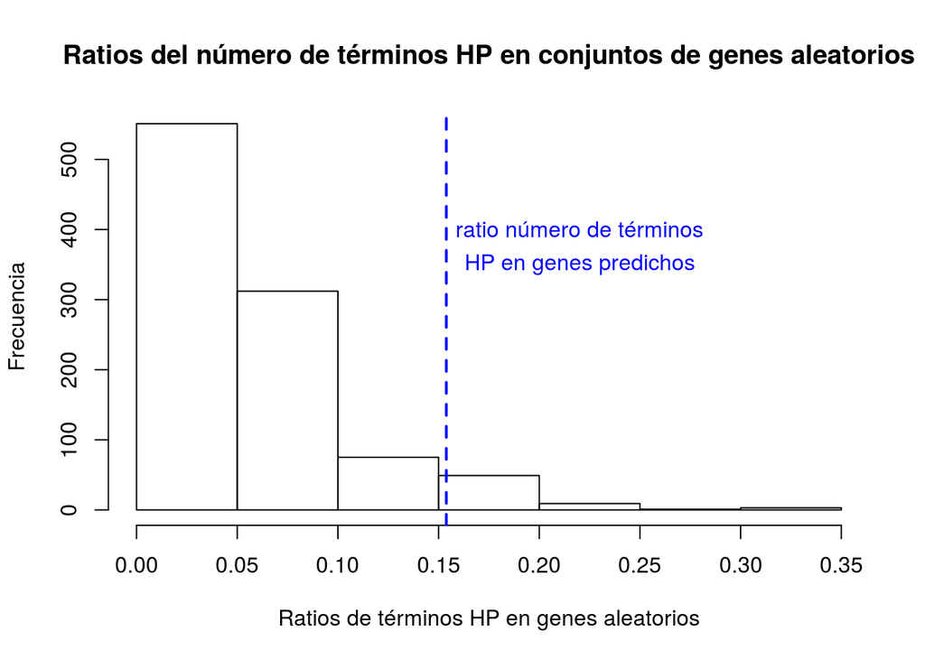

```r
ratiosRandomHP2 <- unlist(ratiosRandomHP, use.names = FALSE)
hist(ratiosRandomHP2, main = "Ratios del número de términos HP en conjuntos de genes aleatorios", xlab = "Ratios de términos HP en genes aleatorios", ylab = "Frecuencia")
# Añadimos una linea vertical que representa el numero de terminos HP en los genes predichos
abline(v = ratioPredichosHP, col="blue", lwd=2, lty=2)
text(0.22, 400, "ratio número de términos", col = "blue")
text(0.22, 350, "HP en genes predichos", col = "blue")
```

En el histograma obtenido, que se corresponde con los conjuntos de genes generados aleatoriamente y la posición del ratio de parejas gen-fenotipo en el conjunto de genes predichos marcada con una línea discontinua azul. Nos permite confirmar visualmente que, el ratio en el conjunto de genes predichos como causantes de EP es mayor de lo esperado por azar.

### 5.2 Número de términos MP asociados a Parkinson en genes aleatorios

A partir de los 1000 subconjuntos de genes obtenidos en el apartado anterior, vamos a utilizar la función que obtiene los términos MP relevantes para Parkinson e introducirlos en un vector:

```r
# Creamos un vector para almacenar el número de fenotipos relevantes en cada subconjunto
numMPrelevantesPD = list()
ratiosRandomMP = list()
# Iteramos sobre la matriz con los 1000 subconjuntos aleatorios de genes y usamos la función que obtiene el número de HP relacionados con Parkinson
for (i in 1:1000) {
conjuntoGenes = as.vector(genesRandom[,i])
numgenesParkRandomMP = genAsociatedWithPhenotype(conjuntoGenes, MouseMinephenotype, MPrelevantesPD)
numMPrelevantesPD = c(numMPrelevantesPD, numgenesParkRandomMP)
ratioMP = (numgenesParkRandomMP/52)
ratiosRandomMP = c(ratiosRandomMP, ratioMP)
}
```

Calculamos el p-valor con la misma fórmula utilizada en el apartado anterior:

```r
# Filtramos los ratios aleatorios que son mayores que los predichos
numRandomMPmayores = which(ratiosRandomMP > ratioPredichosMP)
ratiosRandomMPmayores = length(numRandomMPmayores)
cat("El número de ratios de genes al azar mayores al ratio de genes predichos es:", ratiosRandomMPmayores, "\n")
```

```
## El número de ratios de genes al azar mayores al ratio de genes predichos es: 0
```

```r
# Calculamos el p-valor
pvalorMP = (1 + ratiosRandomMPmayores) / (1 + length(ratiosRandomMP))
cat("El p-valor es:", pvalorMP)
```

```
## El p-valor es: 0.000999001
```

Entre los ratios obtenidos con los 1000 conjuntos de genes aleatorios, no se encontró ningun ratio que fuera mayor que el obtenido en los genes predichos como causantes de Parkinson. El p-valor empírico obtenido es 0,0009 (menor de 0,05), por lo que concluimos que existen diferencias significativas entre los genes predichos y los conjuntos de genes tomados al azar.

[figure not shown]

```r
ratiosRandomMP2 <- unlist(ratiosRandomHP, use.names = FALSE)
hist(ratiosRandomMP2, xlim=c(0,0.5), main = "Ratios del número de términos MP en conjuntos de genes aleatorios", xlab = "Ratios de términos MP en genes aleatorios", ylab = "Frecuencia")
# Añadimos una linea vertical que representa el ratio de terminos MP en los genes predichos
abline(v = ratioPredichosMP, col="blue", lwd=2, lty=2)
text(0.31, 400, "ratio número de términos", col = "blue")
text(0.31, 350, "MP en genes predichos", col = "blue")
```